# SDS315HW7

Somya Krishna

2025-04-02

https://github.com/somya-k535/SDS315HW7.git

# Homework 7

## Problem 1: Armfolding

#### Part A

```
##
## Female   Male
##    111    106
```

```
##
##  2-sample test for equality of proportions with continuity correction
##
## data:  table(armfold$LonR_fold, armfold$Sex)
## X-squared = 0.33454, df = 1, p-value = 0.563
## alternative hypothesis: two.sided
## 95 percent confidence interval:
##  -0.09416038  0.19175488
## sample estimates:
##    prop 1    prop 2
## 0.5333333 0.4845361
```

• **The number of male and female students in the dataset**: 111 females and 106 males.

#### Part B

```
##
##  2-sample test for equality of proportions with continuity correction
##
## data:  c(sum(armfold$LonR_fold[armfold$Sex == "Male"] == 1), sum(armfold$LonR_fold[armfold$Sex == "Female"] == 1)) out of c(sum(armfold$Sex == "Male"), sum(armfold$Sex == "Female"))
## X-squared = 0.33454, df = 1, p-value = 0.563
## alternative hypothesis: two.sided
## 95 percent confidence interval:
##  -0.09315879  0.18970817
## sample estimates:
##    prop 1    prop 2
## 0.4716981 0.4234234
```

```
## [1] 0.04827469
```

**What is the observed difference in proportions between the two groups (males minus females)?**

0.04827469

#### Part C

```
## [1] 0.06745634
```

```
## [1] -0.08393973
```

```
## [1] 0.1804891
```

```
##
##  2-sample test for equality of proportions with continuity correction
##
## data:  c(sum(armfold$LonR_fold[armfold$Sex == "Male"] == 1), sum(armfold$LonR_fold[armfold$Sex == "Female"] == 1)) out of c(num_males, num_females)
## X-squared = 0.33454, df = 1, p-value = 0.563
## alternative hypothesis: two.sided
## 95 percent confidence interval:
##  -0.09315879  0.18970817
## sample estimates:
##    prop 1    prop 2
## 0.4716981 0.4234234
```

Information from built in R-function:

Handwritten Info: • **The formula for the standard error for the difference in proportions:**

• **The values you plugged into the formula**:

**p 1**: sample proportion of males who fold their left hand on top

**N 1**: number of males

**p 2**: sample proportion of females who fold their left hand on top

**N 2**: number of females

The standard error is 0.06745634.

• **The z* value you used and why**

I used 1.96 for the z-value because that corresponds to a 95% confidence interval.

#### Part D

**D. Interpret your confidence interval in context by completing the blanks in this sentence: “If we were to (blank 1), then we would expect that (blank 2).”**

If we were to take repeated samples of the difference in proportions for males minus females that cross left arm over right arm from people in this data science class, then we would expect that the true difference in proportions about 95% of the time to be in between -0.08393973 and 0.1804891.

#### Part E

**E. In your own words, what does the standard error you calculated above represent? What is it measuring?**

The standard error is the standard deviation of a sampling distribution. It tells us how precise our estimate of differences is. In this situation, our standard error is 0.06745634, which is the standard deviation of the distribution of differences for males minus females that cross left arm over right arm from people in this data science class. This number tells us how much of the sample proportions would vary if we took many samples. It is important to help us calculate the confidence interval.

#### Part F

**F. What does the term sampling distribution refer to in this context? Be specific about, what is varying from sample to sample, and what stays fixed.**

In this context, the sampling distribution refers to the difference in proportions for males minus females that cross left arm over right arm from people in this data science class that we expect to see under the same repeated sampling procedure We expect the differences to vary but the sampling procedure to stay the same.

#### Part G

**G. What mathematical result or theorem justifies using a normal distribution to approximate the sampling distribution of the difference in sample proportions? Explain this result briefly in your own words.**

The central limit theorem justifies using a normal distribution to approximate the sampling distribution of the difference in sample proportions because it says that sampling distributions that are based on averages of large sample sizes that are independent (the outcome of one does not affect another outcome) can be modeled as a normal distribution. The sample size is large of this sample of men and women in this data science class, and the outcome of one person’s crossing arms outcome does not affect other people, so we consider the sampling distribution normal.

#### Part H

**H. Suppose your 95% confidence interval for the difference in proportions was [-0.01, 0.30]. Based on this, what would you say to someone who claims “there’s no sex difference in arm folding”?**

#### Part I

**I. Imagine repeating this experiment many times with different random samples of university students. Would the confidence interval be different across samples? Why? What should be true about the collection of all those intervals?**

The confidence intervals would be different because of sampling variability, meaning that there will naturally be different results in different settings. For example, another classroom may just happen to have more men with left arms crossing over than the sample we took in the data science classroom due to chance. The confidence interval also depends on the standard error which is influenced by variability. This means that as the sample data changes, so will the standard error, and therefore the confidence interval. If the sample sizes change, so would the confidence interval. Smaller sample sizes lead to wider confidence intervals because we are not as certain of our result.

In all of the intervals, 95% of the intervals will contain the true population difference in men minus women that cross left over right arms.

## Problem 2: Get out the vote

#### Part A

```
## [1] 0.6477733
```

```
## [1] 0.4442449
```

```
##
##  2-sample test for equality of proportions with continuity correction
##
## data:  c(sum(turnout$GOTV_call == 1 & turnout$voted1998 == 1), sum(turnout$GOTV_call == 0 & turnout$voted1998 == 1)) out of c(sum(turnout$GOTV_call == 1), sum(turnout$GOTV_call == 0))
## X-squared = 39.597, df = 1, p-value = 3.122e-10
## alternative hypothesis: two.sided
## 95 percent confidence interval:
##  0.1411399 0.2659167
## sample estimates:
##    prop 1    prop 2
## 0.6477733 0.4442449
```

• **The proportion of those receiving a GOTV call who voted in 1998.**

0.6477733

• **The sample proportion of those not receiving a GOTV call who voted in 1998.**

0.4442449

• **A large-sample 95% confidence interval for the difference in these two proportions: that is, the proportions of voting in 1998 (voted1998==1) for those who received a GOTV call versus those who didn’t.**

We are 95% confidence that the true difference in the proportion of voting in 1998 for those who received a GOTV call versus those who didn’t is in between 0.1411399 and 0.2659167 if we were to take repeated samples.

#### Part B

```
##
##  2-sample test for equality of proportions with continuity correction
##
## data:  c(sum(turnout$voted1996 == 1 & turnout$GOTV_call == 1), sum(turnout$voted1996 == 0 & turnout$GOTV_call == 1)) out of c(sum(turnout$voted1996 == 1), sum(turnout$voted1996 == 0))
## X-squared = 31.32, df = 1, p-value = 2.188e-08
## alternative hypothesis: two.sided
## 95 percent confidence interval:
##  0.01060767 0.02195834
## sample estimates:
##     prop 1     prop 2
## 0.03038149 0.01409849
```

```
##
##  2-sample test for equality of proportions with continuity correction
##
## data:  c(sum(turnout$AGE > 30 & turnout$GOTV_call == 1), sum(turnout$AGE <= 30 & turnout$GOTV_call == 1)) out of c(sum(turnout$AGE > 30), sum(turnout$AGE <= 30))
## X-squared = 7.2896, df = 1, p-value = 0.006935
## alternative hypothesis: two.sided
## 95 percent confidence interval:
##  0.003966486 0.017012699
## sample estimates:
##     prop 1     prop 2
## 0.02465538 0.01416579
```

```
##
##  2-sample test for equality of proportions with continuity correction
##
## data:  c(sum(turnout$MAJORPTY == 1 & turnout$GOTV_call == 1), sum(turnout$MAJORPTY == 0 & turnout$GOTV_call == 1)) out of c(sum(turnout$MAJORPTY == 1), sum(turnout$MAJORPTY == 0))
## X-squared = 3.8248, df = 1, p-value = 0.0505
## alternative hypothesis: two.sided
## 95 percent confidence interval:
##  0.0004615944 0.0129180093
## sample estimates:
##     prop 1     prop 2
## 0.02450798 0.01781818
```

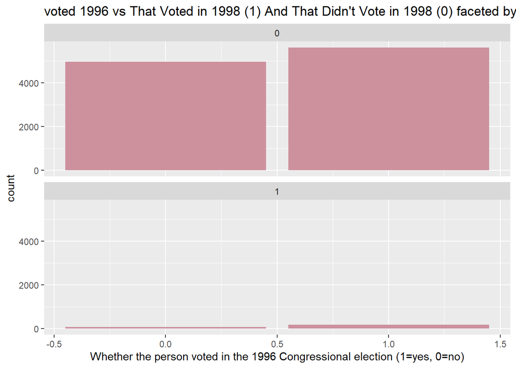

```
## [1] 0.4115409
```

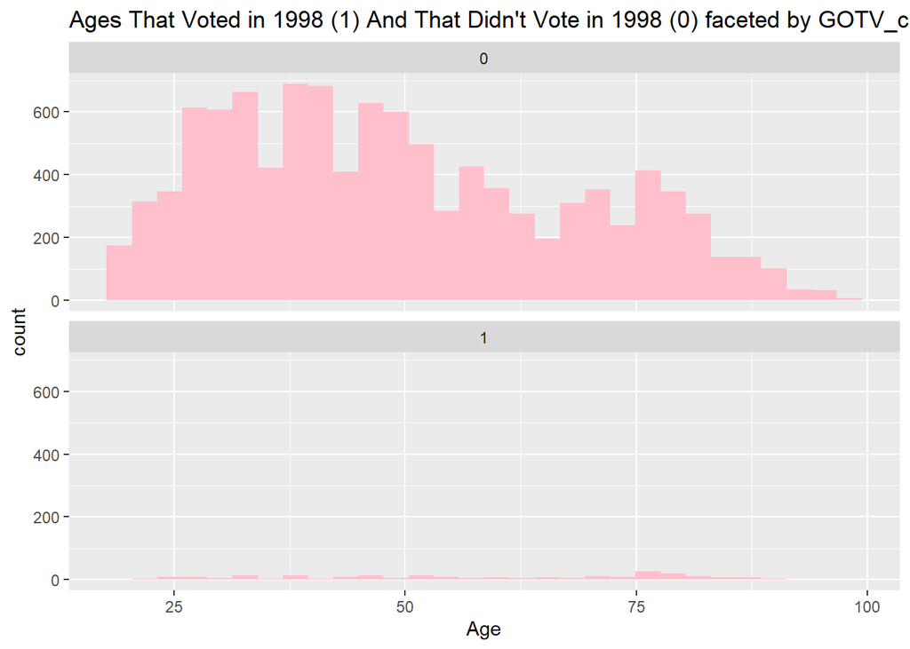

```
## [1] 0.2777855
```

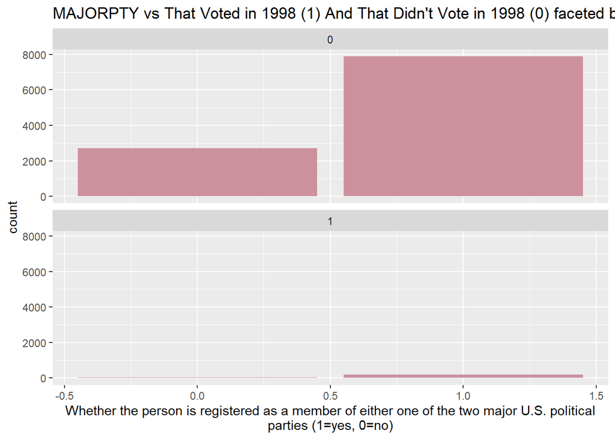

```
## [1] 0.1157816
```

**Consider the voted1996, AGE, and MAJORPTY variables. Provide evidence that at all three of these variables are confounders that prevent the difference you observed in Part A from representing the true causal effect of the GOTV call on the likelihood that a person voted in 1998. Confounders here would be factors that make someone more likely to receive a GOTV call and to have voted in 1998. Your evidence here can consist of any appropriate plot, table, or set of summary statistics, together with an appropriate large-sample confidence interval.**

I used a confidence interval. Since none of the confidence intervals for the variables of voted1996, AGE, and MAJORPTY versus GOTV_call include 0, I conclude that they are confounding variables.

#### Part C

```
##
## Call:
## matchit(formula = GOTV_call ~ voted1996 + AGE + MAJORPTY, data = turnout,
##     ratio = 5)
##
## Summary of Balance for All Data:
##           Means Treated Means Control Std. Mean Diff. Var. Ratio eCDF Mean
## distance         0.0297        0.0226          0.5130     1.3026    0.1572
## voted1996        0.7126        0.5308          0.4016          .    0.1817
## AGE             58.3077       49.4253          0.4475     1.1228    0.1114
## MAJORPTY         0.8016        0.7448          0.1426          .    0.0569
##           eCDF Max
## distance    0.2499
## voted1996   0.1817
## AGE         0.2229
## MAJORPTY    0.0569
##
## Summary of Balance for Matched Data:
##           Means Treated Means Control Std. Mean Diff. Var. Ratio eCDF Mean
## distance         0.0297        0.0297          0.0001      1.004    0.0000
## voted1996        0.7126        0.7126          0.0000          .    0.0000
## AGE             58.3077       58.2664          0.0021      1.008    0.0006
## MAJORPTY         0.8016        0.8073         -0.0142          .    0.0057
##           eCDF Max Std. Pair Dist.
## distance    0.0057          0.0001
## voted1996   0.0000          0.0000
## AGE         0.0057          0.0027
## MAJORPTY    0.0057          0.0183
##
## Sample Sizes:
##           Control Treated
## All         10582     247
## Matched      1235     247
## Unmatched    9347       0
## Discarded       0       0
```

[output not shown]

```
## [1] 0.6477733
```

```
## [1] 0.5692308
```

```
##
##  2-sample test for equality of proportions with continuity correction
##
## data:  c(sum(matched_data$voted1998[matched_data$GOTV_call == 1]), sum(matched_data$voted1998[matched_data$GOTV_call == 0])) out of c(sum(matched_data$GOTV_call == 1), sum(matched_data$GOTV_call == 0))
## X-squared = 4.9027, df = 1, p-value = 0.02682
## alternative hypothesis: two.sided
## 95 percent confidence interval:
##  0.01045353 0.14663149
## sample estimates:
##    prop 1    prop 2
## 0.6477733 0.5692308
```

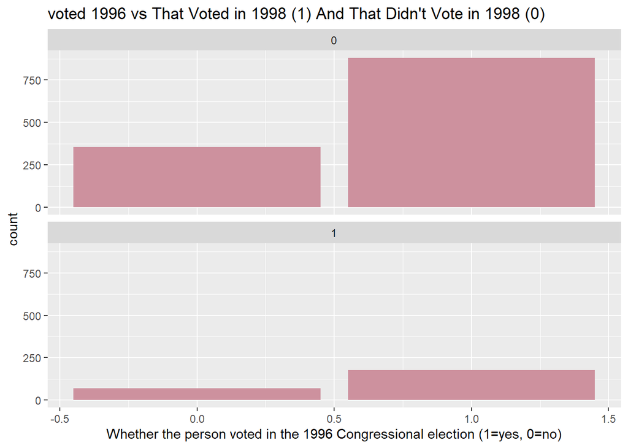

```
## [1] 0.4115409
```

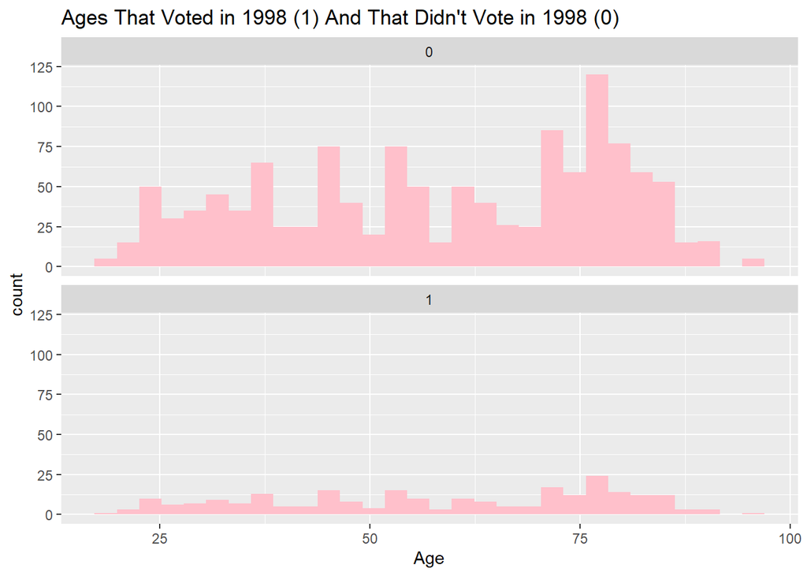

```
## [1] 0.2777855
```

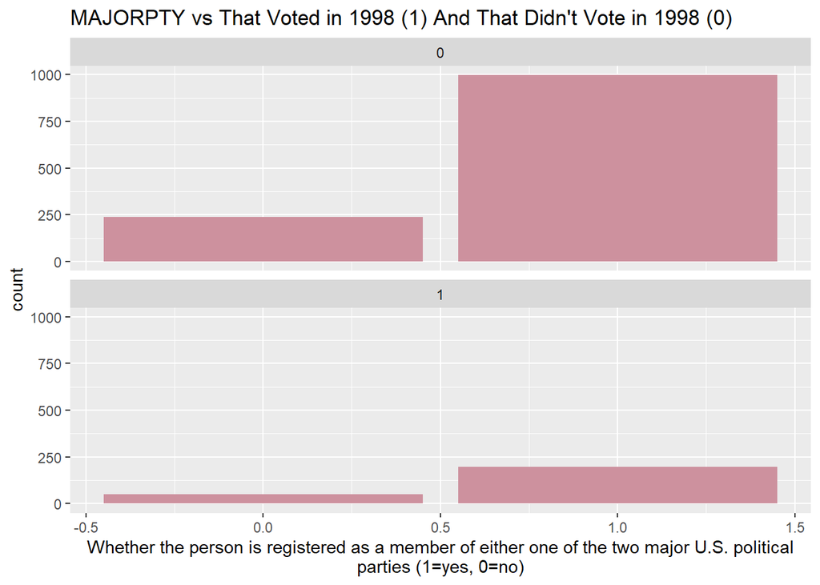

```
## [1] 0.1157816
```

• **The proportion of those receiving a GOTV call who voted in 1998.**

0.6477733

• **The sample proportion of those not receiving a GOTV call who voted in 1998.**

0.5692308

• **A large-sample 95% confidence interval for the difference in these two proportions: that is, the proportions of voting in 1998 (voted1998==1) for those who received a GOTV call versus those who didn’t.**

We are 95% confidence that the true difference in the proportion of voting in 1998 for those who received a GOTV call versus those who didn’t is in between 0.01045353 and 0.14663149 if we were to take repeated samples.

**What do you conclude about the overall effect of the GOTV call on the likelihood of voting in the 1998 election?**

The confidence interval does not include 0 and the p-value is less than 0.05, so I conclude that there is evidence that there is that the GOTV call had a statistically significant effect on voter turnout. We can see from the graphs above that the variables of voted1996, AGE, and MAJORPTY are no longer confounders.